# Old_Library_Heist_Example

Yuling Hsu

2022-11-29

```r
library(usethis)
library(devtools)
library(tidyverse)      # data manipulation & plotting
library(stringr)        # text cleaning and regular expressions
library(tidytext)       # provides additional text mining functions
library(harrypotter)    # provides the first seven novels of the Harry Potter series
library(tm)
```

### Example: the great library heist

Try this out: Go through the library heist example form the [TidyText book](http://tidytextmining.com/topicmodeling.html#library-heist), which is an application of topic modeling.

Suppose a vandal has broken into your study and torn apart four of your following books: “Twenty Thousand Leagues under the Sea”, “The War of the Worlds”, “Pride and Prejudice”, “Great Expectations”

This vandal has torn the books into individual chapters, and left them in one large pile. How can we restore these disorganized chapters to their original books?

```r
titles <- c("Twenty Thousand Leagues under the Sea", "The War of the Worlds",
            "Pride and Prejudice", "Great Expectations")
library(gutenbergr)
books <- gutenberg_works(title %in% titles) %>% # We want to download only four books (in "titles" variable).
  gutenberg_download(meta_fields = "title", mirror = "http://mirrors.xmission.com/gutenberg/") # All mirrors: https://www.gutenberg.org/MIRRORS.ALL
```

Divide into documents, each representing one chapter

```r
by_chapter <- books %>%
  group_by(title) %>%
  mutate(chapter = cumsum(str_detect(text, regex("^chapter ", ignore_case = TRUE)))) %>%
  ungroup() %>%
  filter(chapter > 0) %>%
  unite(document, title, chapter) # Concatenate "title" and "chapter" and create a new variable with name "document" (then remove "title" and "chapter").
by_chapter
```

```
## # A tibble: 46,519 × 3
##    gutenberg_id text                                                     docum…¹
##           <int> <chr>                                                    <chr>
##  1          164 "CHAPTER I"                                              Twenty…
##  2          164 "A SHIFTING REEF"                                        Twenty…
##  3          164 ""                                                       Twenty…
##  4          164 ""                                                       Twenty…
##  5          164 "The year 1866 was signalised by a remarkable incident,… Twenty…
##  6          164 "puzzling phenomenon, which doubtless no one has yet fo… Twenty…
##  7          164 "mention rumours which agitated the maritime population… Twenty…
##  8          164 "public mind, even in the interior of continents, seafa… Twenty…
##  9          164 "particularly excited. Merchants, common sailors, capta… Twenty…
## 10          164 "skippers, both of Europe and America, naval officers o… Twenty…
## # … with 46,509 more rows, and abbreviated variable name ¹document
```

Split into words

```r
by_chapter_word <- by_chapter %>%
  unnest_tokens(word, text)
by_chapter_word
```

```
## # A tibble: 414,716 × 3
##    gutenberg_id document                                word
##           <int> <chr>                                   <chr>
##  1          164 Twenty Thousand Leagues under the Sea_1 chapter
##  2          164 Twenty Thousand Leagues under the Sea_1 i
##  3          164 Twenty Thousand Leagues under the Sea_1 a
##  4          164 Twenty Thousand Leagues under the Sea_1 shifting
##  5          164 Twenty Thousand Leagues under the Sea_1 reef
##  6          164 Twenty Thousand Leagues under the Sea_1 the
##  7          164 Twenty Thousand Leagues under the Sea_1 year
##  8          164 Twenty Thousand Leagues under the Sea_1 1866
##  9          164 Twenty Thousand Leagues under the Sea_1 was
## 10          164 Twenty Thousand Leagues under the Sea_1 signalised
## # … with 414,706 more rows
```

Q.1 Remove stop words and find document-word counts from “by_chapter_word”

```r
# Load the stop words
data(stop_words)

# Remove stop words
by_chapter_word_clean <- by_chapter_word %>%
  anti_join(stop_words)
# Count the words by document
word_counts <- by_chapter_word_clean %>%
  count(gutenberg_id, document, word, sort = TRUE)

word_counts
```

```
## # A tibble: 90,985 × 4
##    gutenberg_id document              word        n
##           <int> <chr>                 <chr>   <int>
##  1         1400 Great Expectations_57 joe        88
##  2         1400 Great Expectations_7  joe        70
##  3         1400 Great Expectations_17 biddy      63
##  4         1400 Great Expectations_27 joe        58
##  5         1400 Great Expectations_38 estella    58
##  6         1400 Great Expectations_2  joe        56
##  7         1400 Great Expectations_23 pocket     53
##  8         1400 Great Expectations_15 joe        50
##  9         1400 Great Expectations_18 joe        50
## 10         1400 Great Expectations_9  joe        44
## # … with 90,975 more rows
```

Right now our data frame word_counts is in a tidy form, with one-term-per-document-per-row, but the topicmodels package requires a DocumentTermMatrix. We can cast a one-token-per-row table into a DocumentTermMatrix with tidytext’s cast_dtm().

Create document-term-matrix (because LDA() expects data in document-term-matrix form).

```r
chapters_dtm <- word_counts %>%
  cast_dtm(document, word, n)
chapters_dtm
```

```
## <<DocumentTermMatrix (documents: 166, terms: 16531)>>
## Non-/sparse entries: 90985/2653161
## Sparsity           : 97%
## Maximal term length: 19
## Weighting          : term frequency (tf)
```

Q.2 Run LDA model with k=4 (because there are 4 books).

```r
library(topicmodels)
chapters_lda <- LDA(chapters_dtm, k = 4, control = list(seed = 1234))
```

Convert result in tidy format.

```r
chapters_lda_td <- tidy(chapters_lda)
chapters_lda_td
```

```
## # A tibble: 66,124 × 3
##    topic term         beta
##    <int> <chr>       <dbl>
##  1     1 joe     9.41e- 54
##  2     2 joe     9.06e- 37
##  3     3 joe     1.59e-  2
##  4     4 joe     1.73e-  3
##  5     1 biddy   3.20e-189
##  6     2 biddy   5.23e- 41
##  7     3 biddy   5.47e-  3
##  8     4 biddy   2.32e- 16
##  9     1 estella 6.02e- 56
## 10     2 estella 1.44e- 28
## # … with 66,114 more rows
```

Q.3. Obtain top 5 terms associated with each book. Hint: Get top 5 terms with respect to “beta” for each book.

```r
ap_top_terms <- chapters_lda_td %>%
  group_by(topic) %>%
  top_n(5, beta) %>% # Take top 10 from each topic
  ungroup() %>%
  arrange(topic, -beta)
```

Q.4. Plot top 5 terms using bar chart in ggplot for each book.

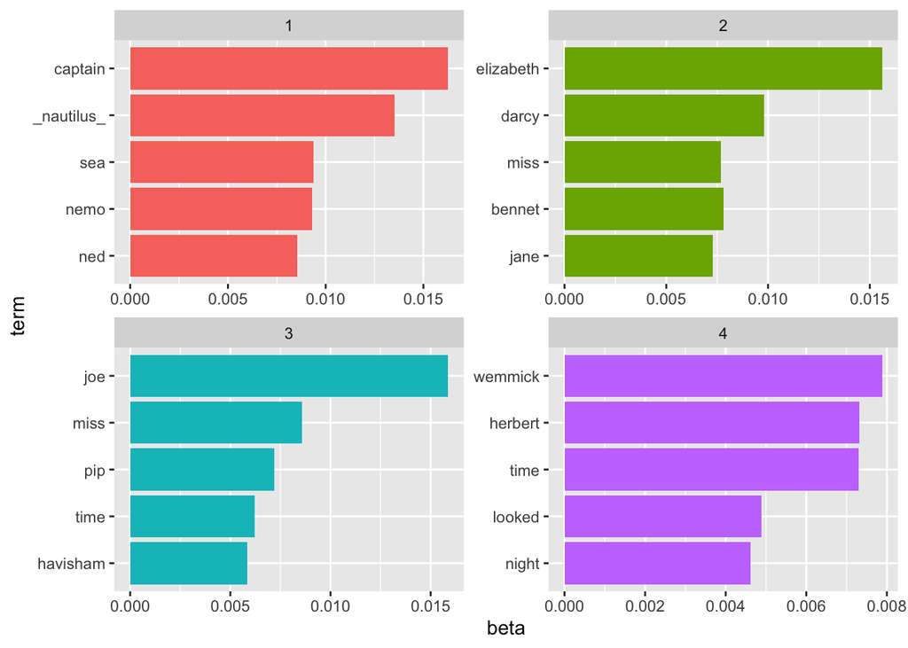

```r
ap_top_terms %>%
  mutate(term = reorder(term, beta)) %>%
  ggplot(aes(term, beta, fill = factor(topic))) +
  geom_bar(stat = "identity", show.legend = FALSE) +
  facet_wrap(~ topic, scales = "free") +
  coord_flip()
```

There’s no question that the topic of “captain”, “nautilus”, “sea”, and “nemo” belongs to Twenty Thousand Leagues Under the Sea, and that “jane”, “darcy”, and “elizabeth” belongs to Pride and Prejudice.

Q.5 Obtain Document topic probabilities (gamma). Hint: Use matrix = “gamma” in tidy()

```r
ap_gamma <- tidy(chapters_lda, matrix = "gamma")
ap_gamma
```

```
## # A tibble: 664 × 3
##    document              topic     gamma
##    <chr>                 <int>     <dbl>
##  1 Great Expectations_57     1 0.0000145
##  2 Great Expectations_7      1 0.0000153
##  3 Great Expectations_17     1 0.0000224
##  4 Great Expectations_27     1 0.0000204
##  5 Great Expectations_38     1 0.0000139
##  6 Great Expectations_2      1 0.0000180
##  7 Great Expectations_23     1 0.0000199
##  8 Great Expectations_15     1 0.0000152
##  9 Great Expectations_18     1 0.0000135
## 10 Great Expectations_9      1 0.0000239
## # … with 654 more rows
```